# 201804_midterm_soln

**Machine Learning for Mechanical Engineering**  
**Midterm Exam**

|  | by Prof. Seungchul Lee Industrial AI Lab POSTECH |
| --- | --- |

- For your handwritten solution, hand in your hardcopy to TA.
- For your code, email your .ipynb file to `iai.postech@gmail.com`. Only .ipynb file will be graded.
- When you send an e-mail, write down [Machine Learning Midterm] on the title
- And please write your NAME on your .ipynb files. ex) 김지원_20182315_Midterm.ipynb
- Do not submit a printed version of your code. It will not be graded.

```python
import numpy as np
import matplotlib.pyplot as plt
import cvxpy as cvx
from six.moves import cPickle
import sounddevice as sd
import cv2
```

# Problem 1

In this problem, we want to explore a reflection transformation of $\vec{X}$, which produces a mirror vector $\vec{Z}$ with respect to vector $\vec{V}$. See Figure 1.

[figure not shown]

Figure 1

(a) Is a reflection transformation linear? If yes, show it.

(b) If yes, find matrix $M$ such that $Z = MX$ using concept of projection.

(c) If yes, find matrix $M$ such that $Z = MX$ using concept of eigen values and vectors. (you can use the results of the above problems)

(d) For $\vec{V} = [\,1 \;\, 1]^T$, compute $M$ and its eigenvalues/eigenvectors (here, vector $\vec{V}$ is a vector with 45 degree angle with x-axis)

# Problem 2

Find solution $d$ of the optimization problem with the following objective function and constraints. Here, $\lVert \cdot \rVert_2$ is the Euclidean norm (or distance).

$$\begin{align*} d= \min_Z \; & \lVert X_1 - Z \rVert_2 + \lVert X_2 - Z \rVert_2 \\ \\ \text{subject to} \;\; & Z \in V=\text{span} \{V_1, V_2\} \end{align*}$$

[figure not shown]

Figure 2

# Problem 3

You need to install sound device packages https://pypi.python.org/pypi/sounddevice

Robert is a suspect of a serial murder case. FBI is wiretapping several possible phone lines in order to identify his location. However, there are not many FBI agencies available to continuously monitor all the lines. Therefore, FBI asks MECH490 students to develop an autonomous audio recognition system. In this special case, FBI wants to know when the sound of ‘Robert’ occurs over a recorded phone conversation.

You can download data from this [link](https://www.dropbox.com/sh/zr3w4pzard49yus/AAAJKvoLbYzgovIYicfoudoLa?dl=1).

1) Consider two time signals $x$ and $y$. Both can be represented as a form of column vector. Write down the inner product of two signal $x$ and $y$, and meaning of it.
$$ x = \begin{bmatrix}x[1]\\x[2]\\\vdots\\x[m] \end{bmatrix},\quad y=\begin{bmatrix} y[1]\\y[2]\\\vdots\\y[m]\end{bmatrix}$$

```python
from six.moves import cPickle
x = cPickle.load(open('./data_files/audio_recording_x.pkl', 'rb'))
y = cPickle.load(open('./data_files/audio_recording_y.pkl', 'rb'))
fs = 48000
```

```python
import sounddevice as sd
sd.play(x, fs)
```

```python
sd.play(y, fs)
```

2) Now we want to create a sound recognition (or audio detection) system using the above concepts (here, use the inner product). Write a code to find when the sound of 'Robert' occurs in signal $x$. Note that lengths of two signals are different.

Hint: Think about correlation (or inner product) when two signals are similar

[figure not shown]

Figure 3

```python
# Your code here

print(np.shape(x), np.shape(y))
m = np.shape(x)[0]
n = np.shape(y)[0]
```

```
(142000,) (10300,)
```

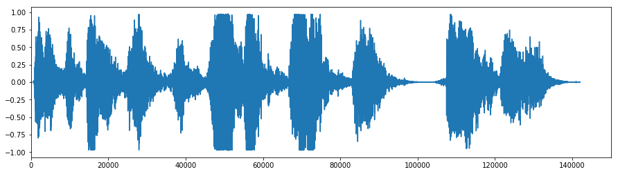

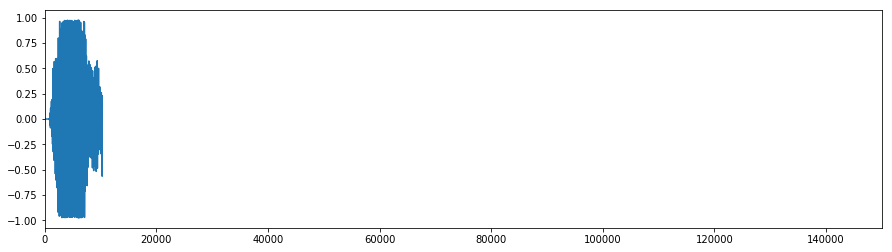

```python
plt.figure(figsize = (15,4))
plt.plot(x)
plt.xlim(0,150000)
plt.show()
plt.figure(figsize = (15,4))
plt.plot(y)
plt.xlim(0,150000)
plt.show()
```

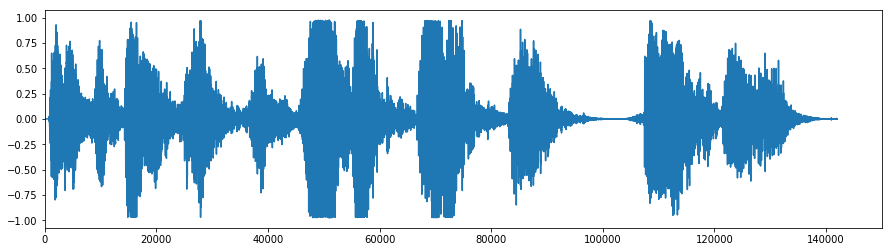

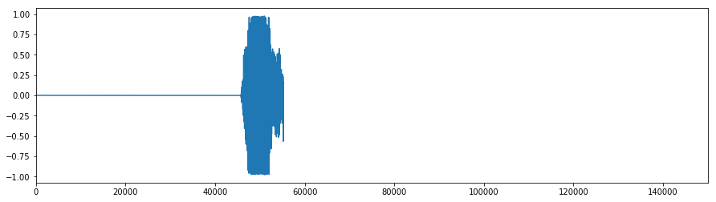

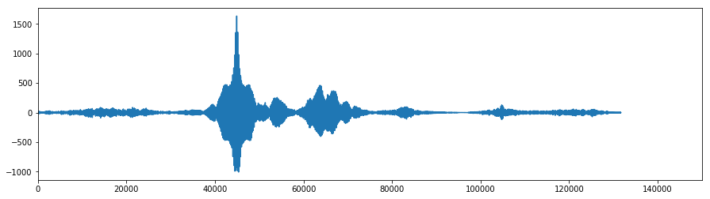

```python
test = []
for i in range(m-n):
    test.append(np.dot(x[i:10300+i], y))

plt.figure(figsize = (15,4))
plt.plot(x)
plt.xlim(0,150000)
plt.show()

np.argmax(test)
y_ = np.hstack([np.zeros([np.argmax(test)]), y])
plt.figure(figsize = (15,4))
plt.plot(y_)
plt.xlim(0,150000)
plt.show()

plt.figure(figsize = (15,4))
plt.plot(test)
plt.xlim(0,150000)
plt.show()
```

# Problem 4

The regularized least-squares problem has the form

$$ \min_{\theta} \;\lVert A\theta -y\rVert_2^2 + \lambda \lVert \theta \rVert_2^2$$

(a) Show that the solution is given by
$$ \hat{\theta} = \left( A^T A + \lambda I_n \right)^{-1} A^T y $$

- Do not use the method of Lagrangian multipliers

(b) Write down a gradient descent algorithm for the given optimization problem.

- Hint: Note that $$ \;\lVert A\theta -y\rVert_2^2 = (A\theta - y)^T(A\theta - y)$$
  Then, you can differentiate the above equation to compute the gradient. Likewise, you can compute the gradient of the regularizer.

(c) Based on the result of (b), describe the role of regularizer term.

- Hint: Gradient $g$ is computed by $ g = g_{\text{projection}} + g_{\text{regularizer}} $.

(d) Describe results of (a) and (b) have the same meaning.

(e) Find and draw an approximated curve of the given data points in Python using your gradient descent algorithm.

```python
import numpy as np
import matplotlib.pyplot as plt
import cvxpy as cvx
from six.moves import cPickle
import cv2
```

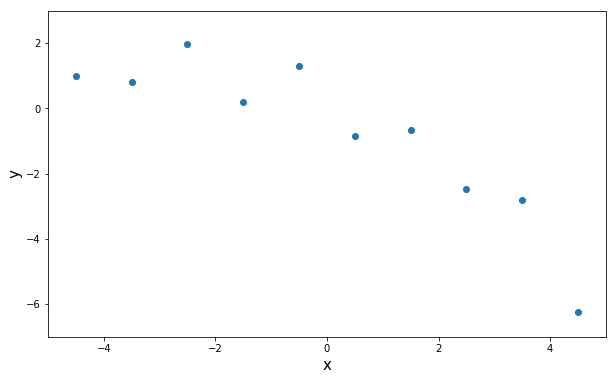

```python
import numpy as np
import matplotlib.pyplot as plt

x = np.linspace(-4.5, 4.5, 10)
y = np.array([0.9819, 0.7973, 1.9737, 0.1838, 1.3180, -0.8361, -0.6591, -2.4701, -2.8122, -6.2512])

plt.figure(figsize=(10, 6))
plt.plot(x, y, 'o')
plt.xlabel('x', fontsize=15)
plt.ylabel('y', fontsize=15)
plt.xlim(-5, 5)
plt.ylim(-7, 3)
plt.show()
```

```python
# your code here

m = np.shape(x)[0]
x = np.reshape(x,(-1,1))
y = np.reshape(y,(-1,1))

X = np.hstack([np.ones([m,1]), x, x**2, x**3, x**4, x**5])
X = np.asmatrix(X)
y = np.asmatrix(y)

theta = np.ones([6,1])
lamda = 1
alpha = 1e-7
n_iter = 1000000

for i in range(n_iter):
    g = 2*X.T*X*theta - 2*X.T*y + 2*lamda*theta
    theta = theta - alpha*g

print(theta)
```

```
[[ 0.40487119]
 [-0.07322881]
 [-0.09691927]
 [-0.07873698]
 [-0.00249385]
 [ 0.00218254]]
```

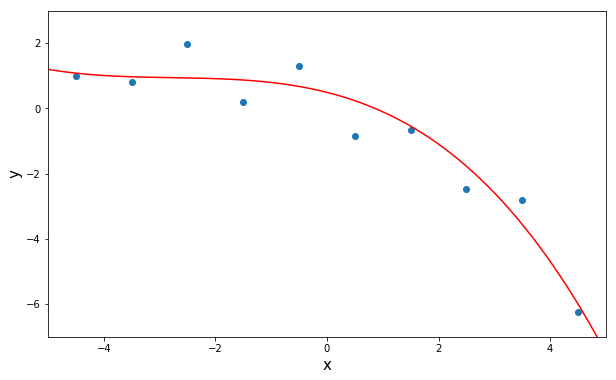

```python
xp = np.linspace(-5,5,1000)
yp = theta[0,0] + theta[1,0]*xp + theta[2,0]*xp**2 + theta[3,0]*xp**3 + \
     theta[4,0]*xp**4 + theta[5,0]*xp**5

plt.figure(figsize = (10,6))
plt.plot(x,y, 'o')
plt.plot(xp,yp, 'r')
plt.xlabel('x', fontsize = 15)
plt.ylabel('y', fontsize = 15)
plt.xlim(-5,5)
plt.ylim(-7,3)
plt.show()
```

# Problem 5

1) Let $f(x_1,x_2) = 2x_1 + 3x_2 + 1 = 0$ be the hyperplane (or decision surface in classification problems). Compute the shortest distances from $x_a = \begin{bmatrix} 2 \\1\end{bmatrix}$ and $x_b = \begin{bmatrix} 1 \\ -1\end{bmatrix}$ to the above hyperplane.

2) Find the solution $r$ of the below optimization problem with the following objective function and constraint. ($x,\omega, \omega_0 \in \mathbb{R}^n$)

$$ \begin{align*} r = \;&\min_x \;\rVert x \lVert_2\\ \text{subject to } &\; \omega^T x + \omega_0 = 0 \end{align*}$$

# Problem 6

In this problem we will refer to the binary classification task depicted in Figure 4, which we attempt to solve with the simple linear logistic regression model

$$ P(y = +1 \mid x,\omega_1, \omega_2) = g(\omega_1 x_1 + \omega_2 x_2) = \frac{1}{1+\exp(-\omega_1 x_1 - \omega_2 x_2)}$$

[output not shown]

$\;\,\, $3. To double check your answers, let's do it in Python. You can include $\omega_3$ to re-use Python files given in class.

$$ \begin{align*} \omega &= \begin{bmatrix} \omega_1 \\ \omega_2 \\ \omega_3\end{bmatrix}, \quad x = \begin{bmatrix} x_1 \\ x_2 \\ 1\end{bmatrix} \end{align*} $$

$$ P(y = +1 \mid x,\omega_1, \omega_2, \omega_3) = g(\omega_1 x_1 + \omega_2 x_2 + \omega_3) = \frac{1}{1+\exp(-\omega_1 x_1 - \omega_2 x_2 - \omega_3)}$$$$ \sum_{i=1}^{m}\log P\left( y_i \mid x_i,\omega_1, \omega_2, \omega_3\right) + \lambda \,\omega_2^2 $$$$ \sum_{i=1}^{m}\log P\left( y_i \mid x_i,\omega_1, \omega_2, \omega_3\right) + \lambda \,\left( \lvert \omega_1 \rvert + \lvert \omega_2 \rvert + \lvert \omega_3 \rvert \right)$$

You can download data from this [link](https://www.dropbox.com/sh/4pffc3evg4d6rgs/AAAtXQrx9ivwWVJe1x6s2uwva?dl=1).

```python
from six.moves import cPickle
x = cPickle.load(open('./data_files/problem6_x.pkl', 'rb'))
y = cPickle.load(open('./data_files/problem6_y.pkl', 'rb'))
```

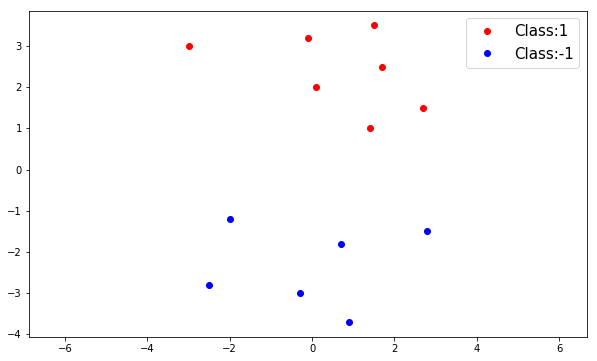

```python
import matplotlib.pyplot as plt

plt.figure(figsize=(10,6))
plt.plot(x[y==1,0], x[y==1,1], 'or', label='Class:1')
plt.plot(x[y==-1,0], x[y==-1,1], 'ob', label='Class:-1')
plt.legend(fontsize=15)
plt.xlim(-5, 5)
plt.axis('equal')
plt.show()
```

```python
# Your code here

m = np.shape(x)[0]
X = np.hstack([np.ones([m,1]), x])
y = np.reshape(y, (-1,1))
```

**Without any penalization**

```
[[ 0.92191326]
 [ 1.33044226]
 [15.77872382]]
```

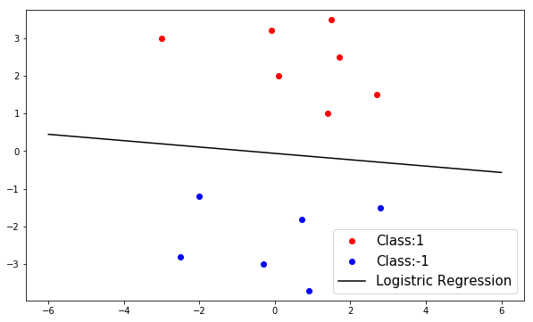

```python
w = cvx.Variable(3,1)
obj = cvx.Minimize(cvx.sum_entries(cvx.logistic(-cvx.mul_elemwise(y,X*w))))
prob = cvx.Problem(obj).solve()

w = w.value

print(w)

xp = np.linspace(-6,6,1000)
yp = -w[1,0]/w[2,0]*xp - w[0,0]/w[2,0]
plt.figure(figsize=(10,6))
plt.plot(X[0:7, 1], X[0:7, 2], 'or', label='Class:1')
plt.plot(X[7:, 1], X[7:, 2], 'ob', label='Class:-1')
plt.plot(xp,yp, 'k', label ='Logistric Regression')
plt.legend(fontsize=15)
plt.xlim(-5,5)
plt.axis('equal')
plt.show()
```

**Regularizing only $\omega_2$**

```
[[0.06631825]
 [0.19379003]
 [0.18805521]]
```

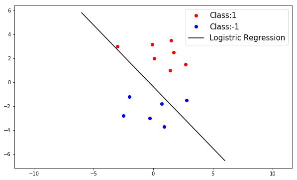

```python
lamda = 30

w = cvx.Variable(3,1)
obj = cvx.Minimize(cvx.sum_entries(cvx.logistic(-cvx.mul_elemwise(y,X*w)))+ lamda*w[2,0]**2)
prob = cvx.Problem(obj).solve()

w = w.value

print(w)

xp = np.linspace(-6,6,1000)
yp = -w[1,0]/w[2,0]*xp - w[0,0]/w[2,0]
plt.figure(figsize=(10,6))
plt.plot(X[0:7, 1], X[0:7, 2], 'or', label='Class:1')
plt.plot(X[7:, 1], X[7:, 2], 'ob', label='Class:-1')
plt.plot(xp,yp, 'k', label ='Logistric Regression')
plt.legend(fontsize=15)
plt.xlim(-5,5)
plt.axis('equal')
plt.show()
```

**$L_1$ norm regularization**

You can change values of $\lambda$ in the following code to see how the linear classifier changes.

```
w1 = [[1.33044226]]
w2 = [[15.77872382]]
```

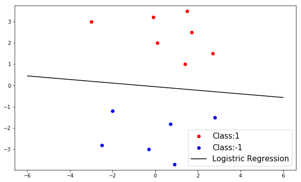

```python
lamda = 0.0

w = cvx.Variable(3,1)
obj = cvx.Minimize(cvx.sum_entries(cvx.logistic(-cvx.mul_elemwise(y,X*w)))+ lamda*cvx.norm(w,1))
prob = cvx.Problem(obj).solve()

w = w.value

print('w1 =', w[1])
print('w2 =', w[2])
xp = np.linspace(-6,6,1000)
yp = -w[1,0]/w[2,0]*xp - w[0,0]/w[2,0]
plt.figure(figsize=(10,6))
plt.plot(X[0:7, 1], X[0:7, 2], 'or', label='Class:1')
plt.plot(X[7:, 1], X[7:, 2], 'ob', label='Class:-1')
plt.plot(xp,yp, 'k', label ='Logistric Regression')
plt.legend(fontsize=15)
plt.xlim(-5,5)
plt.axis('equal')
plt.show()
```

# Problem 7

We examined K-means to compress an image by reducing the number of colors in HW04. We can apply the same method to compress an image down to binary colors (i.e., black and white, and it is the maximum compression). When I, as an instructor, prepare for the lecture materials, I often write some equations down on a whiteboard and take a picture of it to put it in lecture slides as shown in Figure 6. However, if I use it as it is, it will take up a lot of ink or toner when it is printed by a number of students. Since I do not want to waste unnecessary resources and do want to maintain our only one Earth as sustainable as possible, I will ask you to convert it to a binary image which prints only black parts. You can download [handwirtten.jpg](https://www.dropbox.com/s/lb3pywu1zgmdp1o/handwritten.jpg?dl=1)

| Figure 6 | Figure 7 |
| --- | --- |

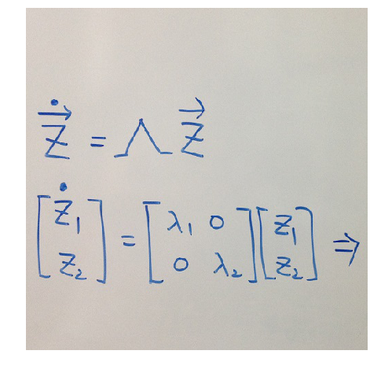

```python
import cv2
import matplotlib.pyplot as plt

img = cv2.imread('./image_files/handwritten.jpg')
img = cv2.cvtColor(img, cv2.COLOR_BGR2RGB)

plt.figure(figsize=(8,8))
plt.imshow(img)
plt.axis('off')
plt.show()
```

```python
# Your code here

k=2

mu = np.array([[255,255,255],[0,0,0]])

m=500

pre_mu=mu.copy()
```

```
0
100.13490899781155
0
0.0
Iteration: 1
```

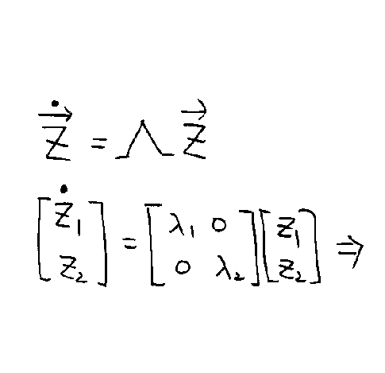

```python
y = np.zeros([m,m])
iter_num = 30

a = np.array([[0,0,0],[255,255,255]])

# Run K-means
for n_iter in range (iter_num) :
    for i in range(500):
            for j in range(500):
                d0 = np.linalg.norm(img[i,j] - mu[0,:],2)
                d1 = np.linalg.norm(img[i,j] - mu[1,:],2)

                y[i,j] = np.argmin([d0, d1])

    err = 0

    for i in range(k):
        mu[i,:] = np.mean(img[np.where(y == i)],axis=0)
        print(err)
        err += np.linalg.norm(pre_mu[i,:] - mu[i,:],2)

    pre_mu = mu.copy()

    if err < 2:
        print("Iteration:", n_iter)
        break

for i in range (2) :
    img[np.where(y==i)]=a[i,:]

plt.figure(figsize=(8, 8))
plt.imshow(img.astype('uint8'))
plt.axis('off')
plt.show()
```